# Soccer's Best Managers

[figure not shown]

#### By Brandon Velasquez and Miles Dobbins

## Introduction

With the beginning of a new decade, we can now reflect on the previous one and in this project we will be focusing on that of the football/soccer world. Throughout the 2010s, there are a few managers that come to mind when you think of those who have been hailed as some of the most prolific football minds of the recent generations. With the tools and data available at our disposal we have decided to put that to the test and see who these managers are and how exactly they stack up against the rest of the managers in the 2010s. Since this tutorial will focus on the different managers throughout the 2010s we will be looking at data from the top 3 leagues in the world, the English Premier League, LaLiga Santander, and Bundesliga.

## Set Up

Listed below are the packages that we will utilize throughout this project. Pandas is used to read in csv files as well as create and fold data inside of their dataframes. Datetime is used to change the formats of dates and times to be easier to manipulate and rearrange. Requests will be used to handle the web scraping for all other incoming data. bs4/BeautifulSoup will be used to read in and make raw HTML and other web scraping data usable. re is used to parse regular expressions to make a more clear and concise data set. The plotting imports are used to create graphs and plots to visually display data. Warnings is imported to help clean up the code.

```python
import pandas as pd
import datetime as dt
from bs4 import BeautifulSoup
import requests
import datetime
import re
import matplotlib.pyplot as plt
from sklearn.linear_model import LinearRegression
from sklearn.model_selection import train_test_split
import numpy as np
import warnings
warnings.filterwarnings('ignore')
```

```python
pd.options.display.max_rows = 20
# pd.options.display.max_rows = 10_000
```

## Data Gathering

The bulk of the data we will be using will be from datahub.io(specific link provided below with the rest of the sources) which provides us with all of the statistical game data minus the data of individual players and staff. The player data is negligible throughout the tutorial so we only need to focus on managers and that data is coming from multiple Wikipedia pages(also listed below). While attempting to wrangle the manager data from wikipedia, we found a discrepancy between the available data for the premier league managers and the managers from both other leagues. The premier league wikipedia page showcases all managers in the premier league with some even dating back to the 1970s whereas the Bundesliga and LaLiga Santander manager lists are only available for individual seasons(i.e. 2009-10, 2011-12, etc.) on separate pages. This process will be discussed more in data tidying.

### Sources

#### Bundesliga

https://en.wikipedia.org/wiki/2009%E2%80%9310_Bundesliga https://en.wikipedia.org/wiki/2010%E2%80%9311_Bundesliga https://en.wikipedia.org/wiki/2011%E2%80%9312_Bundesliga https://en.wikipedia.org/wiki/2012%E2%80%9313_Bundesliga https://en.wikipedia.org/wiki/2013%E2%80%9314_Bundesliga https://en.wikipedia.org/wiki/2014%E2%80%9315_Bundesliga https://en.wikipedia.org/wiki/2015%E2%80%9316_Bundesliga https://en.wikipedia.org/wiki/2016%E2%80%9317_Bundesliga https://en.wikipedia.org/wiki/2017%E2%80%9318_Bundesliga https://en.wikipedia.org/wiki/2018%E2%80%9319_Bundesliga

#### LaLiga

https://en.wikipedia.org/wiki/2009%E2%80%9310_La_Liga https://en.wikipedia.org/wiki/2010%E2%80%9311_La_Liga https://en.wikipedia.org/wiki/2011%E2%80%9312_La_Liga https://en.wikipedia.org/wiki/2012%E2%80%9313_La_Liga https://en.wikipedia.org/wiki/2013%E2%80%9314_La_Liga https://en.wikipedia.org/wiki/2014%E2%80%9315_La_Liga https://en.wikipedia.org/wiki/2015%E2%80%9316_La_Liga https://en.wikipedia.org/wiki/2016%E2%80%9317_La_Liga https://en.wikipedia.org/wiki/2017%E2%80%9318_La_Liga https://en.wikipedia.org/wiki/2018%E2%80%9319_La_Liga

#### Premier League

https://en.wikipedia.org/wiki/List_of_Premier_League_managers

#### Game Data

https://datahub.io/collections/football#football-datasets-on-datahub

## Generating League Datasets

To get the game data into a dataframe, there had to be tweaks made to the date to make the data uniform. Somewhere in the data, the format of the date changed, so functions were added to make the dates all uniform. Lastly, a function was added to create a dataframe of game data given a league name.

```python
def fix_date_1(date):
    # Converts YYYY-MM-DD to Datetime
    return dt.datetime.strptime(date, "%Y-%m-%d")

def convert_date(date):
    # Convert DD/MM/YY
    return dt.datetime.strptime(date, "%d/%m/%y")

def fix_date_2(date):
    # Converts DD/MM/YYYY to Datetime
    return dt.datetime.strptime(date, "%d/%m/%Y")


def get_league_data(league_str):
    dfs = [] # holds each each year DataFrame

    # iterate from 2009-2010 season up to 2018-2019 season
    for year in range(9, 19):
        year_str = "{0:02d}{1:02d}".format(year, year + 1) # ex: 2018-2019 -> 1819
        _df = pd.read_csv(f"https://datahub.io/sports-data/{league_str}/r/season-{year_str}.csv")
        if (year == 9):
            # here we fix date inconsistency prevalent in the 2009-2010 data
            _df['Date'] = _df.apply(lambda x: fix_date_1(x['Date']), axis=1)
        elif (year == 18):
            _df['Date'] = _df.apply(lambda x: fix_date_2(x['Date']), axis=1)
        else:
            _df['Date'] = _df.apply(lambda x: convert_date(x['Date']), axis=1)
        dfs.append(_df)

    # next we combine the data into a single dataset
    ret_df = dfs[0]
    for df in dfs[1:]:
        ret_df = ret_df.append(df, ignore_index=True)

    return ret_df
```

### England

```python
engl_df = get_league_data("english-premier-league")
engl_df.head()
```

|  | Div | Date | HomeTeam | AwayTeam | FTHG | FTAG | FTR | HTHG | HTAG | HTR | ... | BbMxAHH | BbAvAHH | BbMxAHA | BbAvAHA | PSH | PSD | PSA | PSCH | PSCD | PSCA |
| --- | --- | --- | --- | --- | --- | --- | --- | --- | --- | --- | --- | --- | --- | --- | --- | --- | --- | --- | --- | --- | --- |
| 0 | E0 | 2009-08-15 | Aston Villa | Wigan | 0 | 2 | A | 0 | 1 | A | ... | 1.28 | 1.22 | 4.40 | 3.99 | NaN | NaN | NaN | NaN | NaN | NaN |
| 1 | E0 | 2009-08-15 | Blackburn | Man City | 0 | 2 | A | 0 | 1 | A | ... | 2.58 | 2.38 | 1.60 | 1.54 | NaN | NaN | NaN | NaN | NaN | NaN |
| 2 | E0 | 2009-08-15 | Bolton | Sunderland | 0 | 1 | A | 0 | 1 | A | ... | 1.68 | 1.61 | 2.33 | 2.23 | NaN | NaN | NaN | NaN | NaN | NaN |
| 3 | E0 | 2009-08-15 | Chelsea | Hull | 2 | 1 | H | 1 | 1 | D | ... | 1.03 | 1.02 | 17.05 | 12.96 | NaN | NaN | NaN | NaN | NaN | NaN |
| 4 | E0 | 2009-08-15 | Everton | Arsenal | 1 | 6 | A | 0 | 3 | A | ... | 2.27 | 2.20 | 1.73 | 1.63 | NaN | NaN | NaN | NaN | NaN | NaN |

5 rows × 77 columns

### Spain

```python
spain_df = get_league_data("spanish-la-liga")
spain_df.head()
```

|  | Div | Date | HomeTeam | AwayTeam | FTHG | FTAG | FTR | HTHG | HTAG | HTR | ... | BbMxAHH | BbAvAHH | BbMxAHA | BbAvAHA | PSH | PSD | PSA | PSCH | PSCD | PSCA |
| --- | --- | --- | --- | --- | --- | --- | --- | --- | --- | --- | --- | --- | --- | --- | --- | --- | --- | --- | --- | --- | --- |
| 0 | SP1 | 2009-08-29 | Real Madrid | La Coruna | 3 | 2 | H | 2 | 1 | H | ... | 9.00 | 1.92 | 11.00 | 8.69 | NaN | NaN | NaN | NaN | NaN | NaN |
| 1 | SP1 | 2009-08-29 | Zaragoza | Tenerife | 1 | 0 | H | 0 | 0 | D | ... | 1.38 | 1.36 | 3.20 | 3.01 | NaN | NaN | NaN | NaN | NaN | NaN |
| 2 | SP1 | 2009-08-30 | Almeria | Valladolid | 0 | 0 | D | 0 | 0 | D | ... | 1.62 | 1.54 | 2.54 | 2.41 | NaN | NaN | NaN | NaN | NaN | NaN |
| 3 | SP1 | 2009-08-30 | Ath Bilbao | Espanol | 1 | 0 | H | 0 | 0 | D | ... | 1.66 | 1.58 | 2.47 | 2.30 | NaN | NaN | NaN | NaN | NaN | NaN |
| 4 | SP1 | 2009-08-30 | Malaga | Ath Madrid | 3 | 0 | H | 1 | 0 | H | ... | 2.60 | 2.45 | 1.58 | 1.51 | NaN | NaN | NaN | NaN | NaN | NaN |

5 rows × 76 columns

### Germany

```python
german_df = get_league_data("german-bundesliga")
german_df.head()
```

|  | Div | Date | HomeTeam | AwayTeam | FTHG | FTAG | FTR | HTHG | HTAG | HTR | ... | BbMxAHH | BbAvAHH | BbMxAHA | BbAvAHA | PSH | PSD | PSA | PSCH | PSCD | PSCA |
| --- | --- | --- | --- | --- | --- | --- | --- | --- | --- | --- | --- | --- | --- | --- | --- | --- | --- | --- | --- | --- | --- |
| 0 | D1 | 2009-08-07 | Wolfsburg | Stuttgart | 2 | 0 | H | 0 | 0 | D | ... | 1.45 | 1.43 | 2.89 | 2.67 | NaN | NaN | NaN | NaN | NaN | NaN |
| 1 | D1 | 2009-08-08 | Dortmund | FC Koln | 1 | 0 | H | 0 | 0 | D | ... | 1.86 | 1.83 | 2.08 | 2.05 | NaN | NaN | NaN | NaN | NaN | NaN |
| 2 | D1 | 2009-08-08 | Hertha | Hannover | 1 | 0 | H | 0 | 0 | D | ... | 1.33 | 1.31 | 3.35 | 3.19 | NaN | NaN | NaN | NaN | NaN | NaN |
| 3 | D1 | 2009-08-08 | Hoffenheim | Bayern Munich | 1 | 1 | D | 1 | 1 | D | ... | 1.93 | 1.91 | 2.02 | 1.99 | NaN | NaN | NaN | NaN | NaN | NaN |
| 4 | D1 | 2009-08-08 | Mainz | Leverkusen | 2 | 2 | D | 1 | 2 | A | ... | 2.74 | 2.52 | 1.55 | 1.46 | NaN | NaN | NaN | NaN | NaN | NaN |

5 rows × 76 columns

### Merging the League Tables

The following dataframe is a combination of the three dataframes presented above all placed into one table, meaning all games from all 3 leagues from the 2009-10 season to the 2018-19 season are present.

```python
games_df = pd.concat([engl_df, spain_df, german_df], ignore_index=True)
games_df
```

|  | Div | Date | HomeTeam | AwayTeam | FTHG | FTAG | FTR | HTHG | HTAG | HTR | ... | BbMxAHH | BbAvAHH | BbMxAHA | BbAvAHA | PSH | PSD | PSA | PSCH | PSCD | PSCA |
| --- | --- | --- | --- | --- | --- | --- | --- | --- | --- | --- | --- | --- | --- | --- | --- | --- | --- | --- | --- | --- | --- |
| 0 | E0 | 2009-08-15 | Aston Villa | Wigan | 0 | 2 | A | 0 | 1 | A | ... | 1.28 | 1.22 | 4.40 | 3.99 | NaN | NaN | NaN | NaN | NaN | NaN |
| 1 | E0 | 2009-08-15 | Blackburn | Man City | 0 | 2 | A | 0 | 1 | A | ... | 2.58 | 2.38 | 1.60 | 1.54 | NaN | NaN | NaN | NaN | NaN | NaN |
| 2 | E0 | 2009-08-15 | Bolton | Sunderland | 0 | 1 | A | 0 | 1 | A | ... | 1.68 | 1.61 | 2.33 | 2.23 | NaN | NaN | NaN | NaN | NaN | NaN |
| 3 | E0 | 2009-08-15 | Chelsea | Hull | 2 | 1 | H | 1 | 1 | D | ... | 1.03 | 1.02 | 17.05 | 12.96 | NaN | NaN | NaN | NaN | NaN | NaN |
| 4 | E0 | 2009-08-15 | Everton | Arsenal | 1 | 6 | A | 0 | 3 | A | ... | 2.27 | 2.20 | 1.73 | 1.63 | NaN | NaN | NaN | NaN | NaN | NaN |
| ... | ... | ... | ... | ... | ... | ... | ... | ... | ... | ... | ... | ... | ... | ... | ... | ... | ... | ... | ... | ... | ... |
| 10655 | D1 | 2019-05-18 | Mainz | Hoffenheim | 4 | 2 | H | 0 | 2 | A | ... | 1.85 | 1.81 | 2.12 | 2.06 | 4.26 | 4.81 | 1.71 | 4.14 | 4.88 | 1.72 |
| 10656 | D1 | 2019-05-18 | M'gladbach | Dortmund | 0 | 2 | A | 0 | 1 | A | ... | 1.95 | 1.89 | 2.04 | 1.98 | 2.90 | 4.22 | 2.25 | 2.89 | 4.27 | 2.25 |
| 10657 | D1 | 2019-05-18 | Schalke 04 | Stuttgart | 0 | 0 | D | 0 | 0 | D | ... | 2.05 | 2.01 | 1.89 | 1.85 | 1.63 | 4.37 | 5.32 | 1.65 | 4.53 | 4.91 |
| 10658 | D1 | 2019-05-18 | Werder Bremen | RB Leipzig | 2 | 1 | H | 1 | 0 | H | ... | 2.03 | 1.97 | 1.93 | 1.88 | 2.64 | 3.92 | 2.55 | 2.22 | 4.01 | 3.07 |
| 10659 | D1 | 2019-05-18 | Wolfsburg | Augsburg | 8 | 1 | H | 3 | 0 | H | ... | 2.10 | 2.04 | 1.88 | 1.82 | 1.41 | 5.48 | 7.10 | 1.32 | 6.17 | 8.70 |

10660 rows × 77 columns

## Gathering Manager Data for the Leagues

To complement the game data above and to fulfill the purpose of this tutorial, the following is the process required to gather the names of all managers in the top three leagues and the dates within the decade that they were acting manager.

### Premier League

Luckily the Premier League manager data for the decade was contained within one webpage, allowing for us to scrape the data from one table. That is exactly what the following code does. Another function to fix the date was required in the event that a manager is still active today, and that is handled by marking the end date for that manager as today's date tentative to when you view this. Outside of that function, this code reads in the particular table that contains the data we need from the source url and creates a dataframe with the data. The dataframe is then refined to only the required columns.

```python
now = dt.datetime.now()
today = dt.datetime(year=now.year, month=now.month, day=now.day)
today

def fix_date_3(date):
    if date == "Present*":
        # return today's date for times marked present
        return today

    # certain dates have [N #] at the end so it must be removed
    indx = date.find("[")
    if indx != -1:
        date = date[:indx]
    # Converts DD MONTH YYYY to DD/MM/YY
    return dt.datetime.strptime(date, "%d %B %Y")

prem_table = pd.read_html('https://en.wikipedia.org/wiki/List_of_Premier_League_managers')[1]
prem_table = prem_table[["Name", "Club", "From", "Until"]]
prem_table
prem_table['From'] = prem_table.apply(lambda x: fix_date_3(x['From']), axis=1)
prem_table['Until'] = prem_table.apply(lambda x: fix_date_3(x['Until']), axis=1)
prem_table["division"] = "E0"
prem_table
```

|  | Name | Club | From | Until | division |
| --- | --- | --- | --- | --- | --- |
| 0 | George Graham | Arsenal | 1986-05-14 | 1995-02-21 | E0 |
| 1 | Stewart Houston | Arsenal | 1995-02-22 | 1995-06-08 | E0 |
| 2 | Bruce Rioch | Arsenal | 1995-06-08 | 1996-08-12 | E0 |
| 3 | Stewart Houston | Arsenal | 1996-08-12 | 1996-09-13 | E0 |
| 4 | Pat Rice | Arsenal | 1996-09-13 | 1996-09-30 | E0 |
| ... | ... | ... | ... | ... | ... |
| 408 | Terry Burton | Wimbledon | 2000-05-01 | 2002-04-25 | E0 |
| 409 | Dave Jones | Wolverhampton Wanderers | 2001-01-03 | 2004-11-11 | E0 |
| 410 | Mick McCarthy | Wolverhampton Wanderers | 2006-08-05 | 2012-02-14 | E0 |
| 411 | Terry Connor | Wolverhampton Wanderers | 2012-02-24 | 2012-06-30 | E0 |
| 412 | Nuno Espírito Santo | Wolverhampton Wanderers | 2017-05-31 | 2021-05-17 | E0 |

413 rows × 5 columns

### Bundesliga

First, we gather all the tables available at the Bundesliga Wikepedia page.

```python
bund_tables = pd.read_html('https://en.wikipedia.org/wiki/2010%E2%80%9311_Bundesliga')
```

The first table includes season data including the start and end dates which will be useful later on.

```python
season_data = bund_tables[0]
```

Now that we know which table contains the start and end date of each season, those dates are converted to datetime objects and stored.

```python
[_start, _end] = season_data[season_data[0] == "Dates"][1].values[0].split("–") # extracting the values
start = dt.datetime.strptime(_start.strip(), "%d %B %Y") # converting to DateTime objects
end = dt.datetime.strptime(_end.strip(), "%d %B %Y")

print("Start: ", start,"\t End:", end)
```

```
Start:  2010-08-20 00:00:00 	 End: 2011-05-14 00:00:00
```

The following table contains manager (head coach) information for each club in the given season.

```python
manager_table = bund_tables[2]
manager_table = manager_table[["Team", "Head coach"]] # including only necessary columns
```

We then add in the start and end date for the season to each manager.

```python
manager_table['start_date'] = start
manager_table['end_date'] = end
manager_table
```

|  | Team | Head coach | start_date | end_date |
| --- | --- | --- | --- | --- |
| 0 | Bayer Leverkusen | Jupp Heynckes | 2010-08-20 | 2011-05-14 |
| 1 | Bayern Munich | Andries Jonker (caretaker) | 2010-08-20 | 2011-05-14 |
| 2 | Borussia Dortmund | Jürgen Klopp | 2010-08-20 | 2011-05-14 |
| 3 | Borussia Mönchengladbach | Lucien Favre | 2010-08-20 | 2011-05-14 |
| 4 | Eintracht Frankfurt | Christoph Daum | 2010-08-20 | 2011-05-14 |
| 5 | SC Freiburg | Robin Dutt | 2010-08-20 | 2011-05-14 |
| 6 | Hamburger SV | Michael Oenning | 2010-08-20 | 2011-05-14 |
| 7 | Hannover 96 | Mirko Slomka | 2010-08-20 | 2011-05-14 |
| 8 | 1899 Hoffenheim | Marco Pezzaiuoli | 2010-08-20 | 2011-05-14 |
| 9 | 1. FC Kaiserslautern | Marco Kurz | 2010-08-20 | 2011-05-14 |
| 10 | 1. FC Köln | Volker Finke | 2010-08-20 | 2011-05-14 |
| 11 | Mainz 05 | Thomas Tuchel | 2010-08-20 | 2011-05-14 |
| 12 | 1. FC Nürnberg | Dieter Hecking | 2010-08-20 | 2011-05-14 |
| 13 | Schalke 04 | Ralf Rangnick | 2010-08-20 | 2011-05-14 |
| 14 | FC St. Pauli | Holger Stanislawski | 2010-08-20 | 2011-05-14 |
| 15 | VfB Stuttgart | Bruno Labbadia | 2010-08-20 | 2011-05-14 |
| 16 | Werder Bremen | Thomas Schaaf | 2010-08-20 | 2011-05-14 |
| 17 | VfL Wolfsburg | Felix Magath | 2010-08-20 | 2011-05-14 |

Since the Bundesliga information is spread out over so many different webpages, the URLs can be iterated over in a loop since the only things that change are the years. So for each year, the URL is first gathered, then read into a dataframe. The start and end date of the season are extracted and stored. Then the table with the list of managers is extracted into a dataframe and the start and end date are applied to the managers and the complete dataframe is returned.

```python
def _generate_manager_table(year):
    yr = year % 100
    yr1 = "{0:02d}".format(yr)
    yr2 = "{0:02d}".format(yr + 1)
    url = f"https://en.wikipedia.org/wiki/20{yr1}%E2%80%93{yr2}_Bundesliga"
#     print(year, url)
    bund_tables = pd.read_html(url)

    season_data = bund_tables[0]
    [_start, _end] = season_data[season_data[0] == "Dates"][1].values[0].split("–") # extracting the values
    start = dt.datetime.strptime(_start.strip(), "%d %B %Y") # converting to DateTime objects
    end = dt.datetime.strptime(_end.strip(), "%d %B %Y")

    if year == 2013 or year >= 2017:
        manager_table = bund_tables[3]
    else:
        manager_table = bund_tables[2]

#     print(manager_table.head())
    if year == 2015:
        # for 2015 we have to handle the nested table for managers that has
        # `Name` nested under `Manager`
        df1 = manager_table[["Team", "Manager"]]
        df1.columns = ['_'.join(tup).rstrip('_') for tup in df1.columns.values]
        df1 = df1.rename(columns={"Team_Team": "Team", "Manager_Name": "Manager"}) # renaming our columns
        df1 = df1[["Team", "Manager"]]
        manager_table = df1

    if year == 2018:
        # for 2018 we have to handle the nested table for managers
        df1 = manager_table[["Team", "Manager[23]"]]
        df1.columns = ['_'.join(tup).rstrip('_') for tup in df1.columns.values]
        df1 = df1.rename(columns={"Team_Team": "Team", "Manager[23]_Manager[23]": "Manager"}) # renaming our columns
        df1 = df1[["Team", "Manager"]]
        manager_table = df1

    if year == 2017:
        manager_table["Manager"] = manager_table["Manager[45]"]
#     if year == 2018:
#         manager_table["Manager"] = manager_table["Manager[23]"]
    if year >= 2011:
        manager_table['Head coach'] = manager_table['Manager']
    manager_table = manager_table[["Team", "Head coach"]] # including only necessary columns
    manager_table['start_date'] = start
    manager_table['end_date'] = end

    return manager_table
```

The following function is responsible for looping through the previous function and combining for the dataframes that are returned into one comprehensive dataframe.

```python
def generate_manager_table():
    dfs = []
    for year in range(2009, 2019):
        dfs.append(_generate_manager_table(year))

    ret_df = dfs[0]
    for df in dfs[1:]:
#         print(df.head(5))
        ret_df = ret_df.append(df, ignore_index=True)

    return ret_df
```

```python
pd.options.display.max_rows = 20
#pd.options.display.max_rows = 10_000
```

```python
bundesliga_managers = generate_manager_table()
bundesliga_managers['division'] = "D1"
bundesliga_managers
```

|  | Team | Head coach | start_date | end_date | division |
| --- | --- | --- | --- | --- | --- |
| 0 | Bayer 04 Leverkusen | Jupp Heynckes | 2009-08-07 | 2010-05-08 | D1 |
| 1 | FC Bayern Munich | Louis van Gaal | 2009-08-07 | 2010-05-08 | D1 |
| 2 | VfL Bochum | Dariusz Wosz (Interim) | 2009-08-07 | 2010-05-08 | D1 |
| 3 | Borussia Dortmund | Jürgen Klopp | 2009-08-07 | 2010-05-08 | D1 |
| 4 | Eintracht Frankfurt | Michael Skibbe | 2009-08-07 | 2010-05-08 | D1 |
| ... | ... | ... | ... | ... | ... |
| 175 | Bayern Munich | Niko Kovač | 2018-08-24 | 2019-05-18 | D1 |
| 176 | 1. FC Nürnberg | Boris Schommers | 2018-08-24 | 2019-05-18 | D1 |
| 177 | Schalke 04 | Huub Stevens | 2018-08-24 | 2019-05-18 | D1 |
| 178 | VfB Stuttgart | Nico Willig | 2018-08-24 | 2019-05-18 | D1 |
| 179 | VfL Wolfsburg | Bruno Labbadia | 2018-08-24 | 2019-05-18 | D1 |

180 rows × 5 columns

```python
#pd.options.display.max_rows = 20
```

### LaLiga Santander

Creating a dataframe to read in the LaLiga season from the page supplying us with the given year's data.

```python
LLseason = pd.read_html('https://en.wikipedia.org/wiki/2010%E2%80%9311_La_Liga')
```

```python
#LLseason_data = LLseason[0]
```

The given page gives the start and end data of the season within the text, but does not supply it within the overall season data table, so the start and end date were manually entered.

```python
startdt = datetime.datetime(2010, 8, 28)
enddt = datetime.datetime(2011, 5, 21)
```

The table that contains the manager data is placed into the data frame and then refined to only contain the appropriate columns.

```python
LLmanager_table = LLseason[2]
LLmanager_table = LLmanager_table[['Team', 'Head Coach']]
```

This section combines the table that contains the manager name and team for each year with the season's start date and end date to give us a range for that year's managers.

```python
LLmanager_table['start_date'] = startdt
LLmanager_table['end_date'] = enddt
LLmanager_table
```

|  | Team | Head Coach | start_date | end_date |
| --- | --- | --- | --- | --- |
| 0 | Almería | Roberto Olabe | 2010-08-28 | 2011-05-21 |
| 1 | Athletic Bilbao | Joaquín Caparrós | 2010-08-28 | 2011-05-21 |
| 2 | Atlético Madrid | Quique Sánchez Flores | 2010-08-28 | 2011-05-21 |
| 3 | Barcelona | Pep Guardiola | 2010-08-28 | 2011-05-21 |
| 4 | Deportivo La Coruña | Miguel Ángel Lotina | 2010-08-28 | 2011-05-21 |
| 5 | Espanyol | Mauricio Pochettino | 2010-08-28 | 2011-05-21 |
| 6 | Getafe | Míchel | 2010-08-28 | 2011-05-21 |
| 7 | Hércules | Miroslav Đukić | 2010-08-28 | 2011-05-21 |
| 8 | Levante | Luis García Plaza | 2010-08-28 | 2011-05-21 |
| 9 | Málaga | Manuel Pellegrini | 2010-08-28 | 2011-05-21 |
| 10 | Mallorca | Michael Laudrup | 2010-08-28 | 2011-05-21 |
| 11 | Osasuna | José Luis Mendilibar | 2010-08-28 | 2011-05-21 |
| 12 | Racing Santander | Marcelino | 2010-08-28 | 2011-05-21 |
| 13 | Real Madrid | José Mourinho | 2010-08-28 | 2011-05-21 |
| 14 | Real Sociedad | Martín Lasarte | 2010-08-28 | 2011-05-21 |
| 15 | Sevilla | Gregorio Manzano | 2010-08-28 | 2011-05-21 |
| 16 | Sporting de Gijón | Manolo Preciado | 2010-08-28 | 2011-05-21 |
| 17 | Valencia | Unai Emery | 2010-08-28 | 2011-05-21 |
| 18 | Villarreal | Juan Carlos Garrido | 2010-08-28 | 2011-05-21 |
| 19 | Zaragoza | Javier Aguirre | 2010-08-28 | 2011-05-21 |

Since all LaLiga start and end dates had to be gotten manually, two functions are used to give those dates out to the correct years when the larger table is created combining all the years of managers.

```python
def get_startdt(year):
    start_switch = {
        9: datetime.datetime(2009, 8, 29),
        10: datetime.datetime(2010, 8, 28),
        11: datetime.datetime(2011, 8, 27),
        12: datetime.datetime(2012, 8, 18),
        13: datetime.datetime(2013, 8, 17),
        14: datetime.datetime(2014, 8, 23),
        15: datetime.datetime(2015, 8, 21),
        16: datetime.datetime(2016, 8, 19),
        17: datetime.datetime(2017, 8, 18),
        18: datetime.datetime(2018, 8, 17),
    }
    return start_switch.get(year, "invalid year")

def get_enddt(year):
    end_switch = {
        9: datetime.datetime(2010, 5, 16),
        10: datetime.datetime(2011, 5, 21),
        11: datetime.datetime(2012, 5, 13),
        12: datetime.datetime(2013, 6, 1),
        13: datetime.datetime(2014, 5, 18),
        14: datetime.datetime(2015, 5, 24),
        15: datetime.datetime(2016, 5, 15),
        16: datetime.datetime(2017, 5, 21),
        17: datetime.datetime(2018, 5, 20),
        18: datetime.datetime(2019, 5, 19),
    }
    return end_switch.get(year, "invalid year")
```

The following function is responsible for reading in a URL, gettting the start and end date for the given season from the functions above, the extracting the remainder of the manager data from the appropriate table within the HTML. That data is then combined with the start and end dates to create a dataframe with all of the useful information and that dataframe is returned.

```python
def gen_LLmanager_table(year):
    yr = year % 100
    yr1 = "{0:02d}".format(yr)
    yr2 = "{0:02d}".format(yr + 1)
    url = f"https://en.wikipedia.org/wiki/20{yr1}%E2%80%93{yr2}_La_Liga"
    #print(yr1, yr2, url)

    LL_tables = pd.read_html(url)
    startdt = get_startdt(yr)
    enddt = get_enddt(yr)
    #print(LL_tables[2])

    if yr == 9:
        manager_table = LL_tables[3]
    else:
        manager_table = LL_tables[2]

    if yr == 13:
        manager_table = manager_table[['Team', 'Head coach']]
    elif yr == 16 or yr == 19:
        manager_table = manager_table[['Team', 'Manager']]
        manager_table = manager_table.rename(columns={"Manager": "Head coach"})
    elif yr == 17 or yr == 18:
        manager_table = manager_table[['Team', 'Manager[53]']]
        manager_table = manager_table.rename(columns={"Manager[53]": "Head coach"})
    else:
        manager_table = manager_table[['Team', 'Head Coach']]
        manager_table = manager_table.rename(columns={"Head Coach": "Head coach"})

    manager_table['start_date'] = startdt
    manager_table['end_date'] = enddt

    return manager_table
```

The following function loops through the decade, giving us all of the frames returned from the function above and those frames are all put togeher in this function.

```python
def gen_full_LLmanager_table():
    dfs = []
    for year in range(2009, 2019):
        dfs.append(gen_LLmanager_table(year))

    ret_df = dfs[0]
    for df in dfs[1:]:
#         print(df.head(5))
        ret_df = ret_df.append(df, ignore_index=True)

    return ret_df
```

```python
pd.options.display.max_rows = 20
```

```python
laliga_managers = gen_full_LLmanager_table()
laliga_managers["division"] = "SP1"
laliga_managers
```

|  | Team | Head coach | start_date | end_date | division |
| --- | --- | --- | --- | --- | --- |
| 0 | Almería | Juanma Lillo | 2009-08-29 | 2010-05-16 | SP1 |
| 1 | Athletic Bilbao | Joaquín Caparrós | 2009-08-29 | 2010-05-16 | SP1 |
| 2 | Atlético Madrid | Quique Sánchez Flores | 2009-08-29 | 2010-05-16 | SP1 |
| 3 | Barcelona | Pep Guardiola | 2009-08-29 | 2010-05-16 | SP1 |
| 4 | Deportivo La Coruña | Miguel Ángel Lotina | 2009-08-29 | 2010-05-16 | SP1 |
| ... | ... | ... | ... | ... | ... |
| 195 | Real Sociedad | Imanol Alguacil | 2018-08-17 | 2019-05-19 | SP1 |
| 196 | Sevilla | Joaquín Caparrós | 2018-08-17 | 2019-05-19 | SP1 |
| 197 | Valencia | Marcelino | 2018-08-17 | 2019-05-19 | SP1 |
| 198 | Valladolid | Sergio González | 2018-08-17 | 2019-05-19 | SP1 |
| 199 | Villarreal | Javier Calleja | 2018-08-17 | 2019-05-19 | SP1 |

200 rows × 5 columns

## Data Tidying

Now that all of the neccessary data has been gathered and grouped, it can now be further combined and molded to what we need for analysis reasons. There has been much data tidying done up to this point in the tutorial, much of it dealing with inconsistent dates and titles. The data tidying that will be done from this point forward will be to aid in the analysis process.

### Merging the Manager Tables

The first part to merging the manager tables is to make sure all data between the three different leagues is uniform. The Bundesliga and LaLiga data tables sometimes contained extra data which to this tutorial is unneccessary, so it must be removed.

```python
managers = pd.concat([bundesliga_managers, laliga_managers], ignore_index=True)

def clean_managers(manager):
    m = re.match(r"(.*)\(.*\)", manager)
    if m is None:
        return manager
    return m.group(1).strip()

managers['Head coach'] = managers.apply(lambda x: clean_managers(x['Head coach']), axis=1)
managers = managers.rename(columns={"Team": "team", "Head coach": "manager"})
```

To unify the remaining table, the premier league table must have the same column names then they can properly be merged.

```python
prem_table.head()
col_mapping = {"Name": "manager", "Club": "team", "From": "start_date", "Until": "end_date"}
_prem_table = prem_table.rename(columns=col_mapping)
_prem_table = _prem_table[["team", "manager", "start_date", "end_date", "division"]]

managers = pd.concat([managers, _prem_table], ignore_index=True)
```

```python
pd.options.display.max_rows = 20
```

```python
managers
```

|  | team | manager | start_date | end_date | division |
| --- | --- | --- | --- | --- | --- |
| 0 | Bayer 04 Leverkusen | Jupp Heynckes | 2009-08-07 | 2010-05-08 | D1 |
| 1 | FC Bayern Munich | Louis van Gaal | 2009-08-07 | 2010-05-08 | D1 |
| 2 | VfL Bochum | Dariusz Wosz | 2009-08-07 | 2010-05-08 | D1 |
| 3 | Borussia Dortmund | Jürgen Klopp | 2009-08-07 | 2010-05-08 | D1 |
| 4 | Eintracht Frankfurt | Michael Skibbe | 2009-08-07 | 2010-05-08 | D1 |
| ... | ... | ... | ... | ... | ... |
| 788 | Wimbledon | Terry Burton | 2000-05-01 | 2002-04-25 | E0 |
| 789 | Wolverhampton Wanderers | Dave Jones | 2001-01-03 | 2004-11-11 | E0 |
| 790 | Wolverhampton Wanderers | Mick McCarthy | 2006-08-05 | 2012-02-14 | E0 |
| 791 | Wolverhampton Wanderers | Terry Connor | 2012-02-24 | 2012-06-30 | E0 |
| 792 | Wolverhampton Wanderers | Nuno Espírito Santo | 2017-05-31 | 2021-05-17 | E0 |

793 rows × 5 columns

Since we got our data from two seperate sources, there were some discrepancies with regards to team names, as some team names can get rather lengthy. To eliminate this, a seperate csv file was created that created an association between the different team names.

```python
pd.DataFrame(managers['team'].unique(), columns=['wiki_team']).sort_values(by=['wiki_team']) \
    .to_csv("wiki_teams.csv", index=False)
```

```python
pd.DataFrame(games_df['HomeTeam'].unique(), columns=['datahub_team']).sort_values(by=['datahub_team']) \
    .to_csv("datahub_teams.csv", index=False)
```

A new dataframe is created using the csv file that was created and the managers that are not being focused on during this decade are dropped.

```python
df = pd.read_csv("https://bv2000-image-test.s3.us-east-2.amazonaws.com/github_io/team_mapping.csv").dropna() # prem managers not in our time period
df
```

|  | wiki_team | datahub_team |
| --- | --- | --- |
| 0 | 1. FC Kaiserslautern | Kaiserslautern |
| 1 | 1. FC Köln | FC Koln |
| 2 | 1. FC Nürnberg | Nurnberg |
| 3 | 1. FSV Mainz 05 | Mainz |
| 4 | 1899 Hoffenheim | Hoffenheim |
| ... | ... | ... |
| 116 | West Ham United | West Ham |
| 117 | Wigan Athletic | Wigan |
| 119 | Wolverhampton Wanderers | Wolves |
| 120 | Xerez | Xerez |
| 121 | Zaragoza | Zaragoza |

109 rows × 2 columns

```python
# df1.merge(df2, left_on='lkey', right_on='rkey')
_managers = managers.copy()
_managers = _managers.merge(df, left_on='team', right_on='wiki_team')

managers = _managers[["datahub_team", "manager", "start_date", "end_date", "division"]]
managers = managers.rename(columns={"datahub_team": "team"})
managers
```

|  | team | manager | start_date | end_date | division |
| --- | --- | --- | --- | --- | --- |
| 0 | Leverkusen | Jupp Heynckes | 2009-08-07 | 2010-05-08 | D1 |
| 1 | Bayern Munich | Louis van Gaal | 2009-08-07 | 2010-05-08 | D1 |
| 2 | Bochum | Dariusz Wosz | 2009-08-07 | 2010-05-08 | D1 |
| 3 | Dortmund | Jürgen Klopp | 2009-08-07 | 2010-05-08 | D1 |
| 4 | Dortmund | Jürgen Klopp | 2010-08-20 | 2011-05-14 | D1 |
| ... | ... | ... | ... | ... | ... |
| 737 | Wigan | Roberto Martínez | 2009-06-15 | 2013-05-28 | E0 |
| 738 | Wolves | Dave Jones | 2001-01-03 | 2004-11-11 | E0 |
| 739 | Wolves | Mick McCarthy | 2006-08-05 | 2012-02-14 | E0 |
| 740 | Wolves | Terry Connor | 2012-02-24 | 2012-06-30 | E0 |
| 741 | Wolves | Nuno Espírito Santo | 2017-05-31 | 2021-05-17 | E0 |

742 rows × 5 columns

## Merging the Manager and Game Data

```python
games_df = games_df[["Div", "Date", "HomeTeam", "AwayTeam", "FTHG", "FTAG", "FTR", "HTHG", "HTAG", "HTR"]]
```

```python
games_df
```

|  | Div | Date | HomeTeam | AwayTeam | FTHG | FTAG | FTR | HTHG | HTAG | HTR |
| --- | --- | --- | --- | --- | --- | --- | --- | --- | --- | --- |
| 0 | E0 | 2009-08-15 | Aston Villa | Wigan | 0 | 2 | A | 0 | 1 | A |
| 1 | E0 | 2009-08-15 | Blackburn | Man City | 0 | 2 | A | 0 | 1 | A |
| 2 | E0 | 2009-08-15 | Bolton | Sunderland | 0 | 1 | A | 0 | 1 | A |
| 3 | E0 | 2009-08-15 | Chelsea | Hull | 2 | 1 | H | 1 | 1 | D |
| 4 | E0 | 2009-08-15 | Everton | Arsenal | 1 | 6 | A | 0 | 3 | A |
| ... | ... | ... | ... | ... | ... | ... | ... | ... | ... | ... |
| 10655 | D1 | 2019-05-18 | Mainz | Hoffenheim | 4 | 2 | H | 0 | 2 | A |
| 10656 | D1 | 2019-05-18 | M'gladbach | Dortmund | 0 | 2 | A | 0 | 1 | A |
| 10657 | D1 | 2019-05-18 | Schalke 04 | Stuttgart | 0 | 0 | D | 0 | 0 | D |
| 10658 | D1 | 2019-05-18 | Werder Bremen | RB Leipzig | 2 | 1 | H | 1 | 0 | H |
| 10659 | D1 | 2019-05-18 | Wolfsburg | Augsburg | 8 | 1 | H | 3 | 0 | H |

10660 rows × 10 columns

```python
df = games_df.merge(managers, left_on='HomeTeam', right_on='team').drop("division", 1)
```

```python
df
```

|  | Div | Date | HomeTeam | AwayTeam | FTHG | FTAG | FTR | HTHG | HTAG | HTR | team | manager | start_date | end_date |
| --- | --- | --- | --- | --- | --- | --- | --- | --- | --- | --- | --- | --- | --- | --- |
| 0 | E0 | 2009-08-15 | Aston Villa | Wigan | 0 | 2 | A | 0 | 1 | A | Aston Villa | Ron Atkinson | 1991-06-07 | 1994-11-10 |
| 1 | E0 | 2009-08-15 | Aston Villa | Wigan | 0 | 2 | A | 0 | 1 | A | Aston Villa | Brian Little | 1994-11-25 | 1998-02-24 |
| 2 | E0 | 2009-08-15 | Aston Villa | Wigan | 0 | 2 | A | 0 | 1 | A | Aston Villa | John Gregory | 1998-02-25 | 2002-01-24 |
| 3 | E0 | 2009-08-15 | Aston Villa | Wigan | 0 | 2 | A | 0 | 1 | A | Aston Villa | John Deehan | 2002-01-24 | 2002-02-05 |
| 4 | E0 | 2009-08-15 | Aston Villa | Wigan | 0 | 2 | A | 0 | 1 | A | Aston Villa | Stuart Gray | 2002-01-24 | 2002-02-05 |
| ... | ... | ... | ... | ... | ... | ... | ... | ... | ... | ... | ... | ... | ... | ... |
| 102064 | D1 | 2019-04-27 | RB Leipzig | Freiburg | 2 | 1 | H | 1 | 0 | H | RB Leipzig | Ralph Hasenhüttl | 2017-08-18 | 2018-05-12 |
| 102065 | D1 | 2019-04-27 | RB Leipzig | Freiburg | 2 | 1 | H | 1 | 0 | H | RB Leipzig | Ralf Rangnick | 2018-08-24 | 2019-05-18 |
| 102066 | D1 | 2019-05-11 | RB Leipzig | Bayern Munich | 0 | 0 | D | 0 | 0 | D | RB Leipzig | Ralph Hasenhüttl | 2016-08-26 | 2017-05-20 |
| 102067 | D1 | 2019-05-11 | RB Leipzig | Bayern Munich | 0 | 0 | D | 0 | 0 | D | RB Leipzig | Ralph Hasenhüttl | 2017-08-18 | 2018-05-12 |
| 102068 | D1 | 2019-05-11 | RB Leipzig | Bayern Munich | 0 | 0 | D | 0 | 0 | D | RB Leipzig | Ralf Rangnick | 2018-08-24 | 2019-05-18 |

102069 rows × 14 columns

```python
df1 = df.copy()
df2 = df1[df1['Date'] >= df1['start_date']]
df3 = df2[df2['Date'] <= df2['end_date']]
df3 = df3.drop(["start_date", "team", "end_date"], 1)
df4 = df3.rename(columns={"manager": "h_manager"})
df4
```

|  | Div | Date | HomeTeam | AwayTeam | FTHG | FTAG | FTR | HTHG | HTAG | HTR | h_manager |
| --- | --- | --- | --- | --- | --- | --- | --- | --- | --- | --- | --- |
| 7 | E0 | 2009-08-15 | Aston Villa | Wigan | 0 | 2 | A | 0 | 1 | A | Martin O'Neill |
| 26 | E0 | 2009-08-30 | Aston Villa | Fulham | 2 | 0 | H | 1 | 0 | H | Martin O'Neill |
| 45 | E0 | 2009-09-19 | Aston Villa | Portsmouth | 2 | 0 | H | 2 | 0 | H | Martin O'Neill |
| 64 | E0 | 2009-10-05 | Aston Villa | Man City | 1 | 1 | D | 1 | 0 | H | Martin O'Neill |
| 83 | E0 | 2009-10-17 | Aston Villa | Chelsea | 2 | 1 | H | 1 | 1 | D | Martin O'Neill |
| ... | ... | ... | ... | ... | ... | ... | ... | ... | ... | ... | ... |
| 102056 | D1 | 2019-03-09 | RB Leipzig | Augsburg | 0 | 0 | D | 0 | 0 | D | Ralf Rangnick |
| 102059 | D1 | 2019-03-30 | RB Leipzig | Hertha | 5 | 0 | H | 2 | 0 | H | Ralf Rangnick |
| 102062 | D1 | 2019-04-13 | RB Leipzig | Wolfsburg | 2 | 0 | H | 2 | 0 | H | Ralf Rangnick |
| 102065 | D1 | 2019-04-27 | RB Leipzig | Freiburg | 2 | 1 | H | 1 | 0 | H | Ralf Rangnick |
| 102068 | D1 | 2019-05-11 | RB Leipzig | Bayern Munich | 0 | 0 | D | 0 | 0 | D | Ralf Rangnick |

10667 rows × 11 columns

```python
df5 = df4.merge(managers, left_on='AwayTeam', right_on='team').drop("division", 1)
df5 = df5[df5['Date'] >= df5['start_date']]
df5 = df5[df5['Date'] <= df5['end_date']]
df5 = df5.drop(["start_date", "team", "end_date"], 1)
full_data = df5.rename(columns={"manager": "a_manager"})
full_data
```

|  | Div | Date | HomeTeam | AwayTeam | FTHG | FTAG | FTR | HTHG | HTAG | HTR | h_manager | a_manager |
| --- | --- | --- | --- | --- | --- | --- | --- | --- | --- | --- | --- | --- |
| 4 | E0 | 2009-08-15 | Aston Villa | Wigan | 0 | 2 | A | 0 | 1 | A | Martin O'Neill | Roberto Martínez |
| 9 | E0 | 2011-05-07 | Aston Villa | Wigan | 1 | 1 | D | 1 | 1 | D | Gérard Houllier | Roberto Martínez |
| 14 | E0 | 2011-05-07 | Aston Villa | Wigan | 1 | 1 | D | 1 | 1 | D | Gary McAllister | Roberto Martínez |
| 19 | E0 | 2011-10-01 | Aston Villa | Wigan | 2 | 0 | H | 1 | 0 | H | Alex McLeish | Roberto Martínez |
| 24 | E0 | 2012-12-29 | Aston Villa | Wigan | 0 | 3 | A | 0 | 1 | A | Paul Lambert | Roberto Martínez |
| ... | ... | ... | ... | ... | ... | ... | ... | ... | ... | ... | ... | ... |
| 102090 | D1 | 2015-09-12 | Ingolstadt | Wolfsburg | 0 | 0 | D | 0 | 0 | D | Ralph Hasenhüttl | Dieter Hecking |
| 102101 | D1 | 2016-11-26 | Ingolstadt | Wolfsburg | 1 | 1 | D | 1 | 0 | H | Maik Walpurgis | Andries Jonker |
| 102111 | D1 | 2017-03-11 | RB Leipzig | Wolfsburg | 0 | 1 | A | 0 | 1 | A | Ralph Hasenhüttl | Andries Jonker |
| 102122 | D1 | 2018-05-05 | RB Leipzig | Wolfsburg | 4 | 1 | H | 2 | 0 | H | Ralph Hasenhüttl | Bruno Labbadia |
| 102133 | D1 | 2019-04-13 | RB Leipzig | Wolfsburg | 2 | 0 | H | 2 | 0 | H | Ralf Rangnick | Bruno Labbadia |

10677 rows × 12 columns

# Exploratory data analysis

## Win-Lose Ratio

```python
_full_data = full_data.copy()
```

```python
home_wl = _full_data[["h_manager", "FTR"]]
home_wl
```

|  | h_manager | FTR |
| --- | --- | --- |
| 4 | Martin O'Neill | A |
| 9 | Gérard Houllier | D |
| 14 | Gary McAllister | D |
| 19 | Alex McLeish | H |
| 24 | Paul Lambert | A |
| ... | ... | ... |
| 102090 | Ralph Hasenhüttl | D |
| 102101 | Maik Walpurgis | D |
| 102111 | Ralph Hasenhüttl | A |
| 102122 | Ralph Hasenhüttl | H |
| 102133 | Ralf Rangnick | H |

10677 rows × 2 columns

```python
wl_h_mapping = {
    "H": "W",
    "A": "L",
    "D": "D",
}

home_wl["result"] = home_wl.apply(lambda x: wl_h_mapping.get(x['FTR']), axis=1)
home_wl = home_wl.rename(columns={"h_manager": "manager"})
home_wl
```

|  | manager | FTR | result |
| --- | --- | --- | --- |
| 4 | Martin O'Neill | A | L |
| 9 | Gérard Houllier | D | D |
| 14 | Gary McAllister | D | D |
| 19 | Alex McLeish | H | W |
| 24 | Paul Lambert | A | L |
| ... | ... | ... | ... |
| 102090 | Ralph Hasenhüttl | D | D |
| 102101 | Maik Walpurgis | D | D |
| 102111 | Ralph Hasenhüttl | A | L |
| 102122 | Ralph Hasenhüttl | H | W |
| 102133 | Ralf Rangnick | H | W |

10677 rows × 3 columns

```python
away_wl = _full_data[["a_manager", "FTR"]]

wl_a_mapping = {
    "A": "W",
    "H": "L",
    "D": "D",
}

away_wl["result"] = away_wl.apply(lambda x: wl_a_mapping.get(x['FTR']), axis=1)
away_wl = away_wl.rename(columns={"a_manager": "manager"})
away_wl
```

|  | manager | FTR | result |
| --- | --- | --- | --- |
| 4 | Roberto Martínez | A | W |
| 9 | Roberto Martínez | D | D |
| 14 | Roberto Martínez | D | D |
| 19 | Roberto Martínez | H | L |
| 24 | Roberto Martínez | A | W |
| ... | ... | ... | ... |
| 102090 | Dieter Hecking | D | D |
| 102101 | Andries Jonker | D | D |
| 102111 | Andries Jonker | A | W |
| 102122 | Bruno Labbadia | H | L |
| 102133 | Bruno Labbadia | H | L |

10677 rows × 3 columns

```python
manager_ft_results = pd.concat([home_wl, away_wl], ignore_index=True).drop(columns=["FTR"])
```

```python
manager_ft_wins = manager_ft_results[manager_ft_results['result'] == "W"]
manager_ft_wins['wins']= manager_ft_wins.groupby('manager')['result'].transform('count')
manager_ft_wins = manager_ft_wins.drop(columns=['result']).drop_duplicates()

manager_ft_losses = manager_ft_results[manager_ft_results['result'] == "L"]
manager_ft_losses['losses']= manager_ft_losses.groupby('manager')['result'].transform('count')
manager_ft_losses = manager_ft_losses.drop(columns=['result']).drop_duplicates()
manager_ft_losses

manager_ft_draws = manager_ft_results[manager_ft_results['result'] == "D"]
manager_ft_draws['draws']= manager_ft_draws.groupby('manager')['result'].transform('count')
manager_ft_draws = manager_ft_draws.drop(columns=['result']).drop_duplicates()

_df = manager_ft_wins.merge(manager_ft_losses, on='manager')
_df = _df.merge(manager_ft_draws, on='manager')
_df['gp'] = _df.apply(lambda x: x['wins'] + x['losses'] + x['draws'], axis=1)
_df
_wl_df = _df.copy()
_wl_df['wl_ratio'] = _wl_df.apply(lambda x: x["wins"] / x["losses"], axis=1)
_wl_df['gp'] = _df['gp']
wl_df = _wl_df.sort_values(by=['wl_ratio'], ascending=False)[["manager", "wl_ratio", "gp"]]
wl_df.head()
```

|  | manager | wl_ratio | gp |
| --- | --- | --- | --- |
| 109 | Tito Vilanova | 16.000000 | 38 |
| 40 | Pep Guardiola | 9.555556 | 330 |
| 142 | Gerardo Martino | 5.400000 | 38 |
| 9 | Alex Ferguson | 5.047619 | 152 |
| 194 | Jupp Heynckes | 4.956522 | 170 |

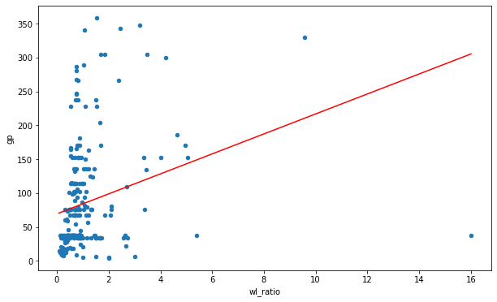

```python
# generating the scatter plot
ax = wl_df.plot.scatter(x='wl_ratio', y='gp', figsize=(10,6))

wl_ratio = np.array(wl_df["wl_ratio"]).reshape(-1, 1)
gp = np.array(_df['gp']).reshape(-1, 1)
reg1 = LinearRegression().fit(wl_ratio, gp)
plt.plot(wl_ratio, reg1.intercept_ + reg1.coef_ * wl_ratio, '-', color='Red')
```

The graph shows us that the majority of managers fall within a reasonable win loss ratio no matter how many games are played. But the small amount of divergence from the majority of the data shows us that there is a number of managers that have outstanding win loss ratios while also playing a significant number of games.

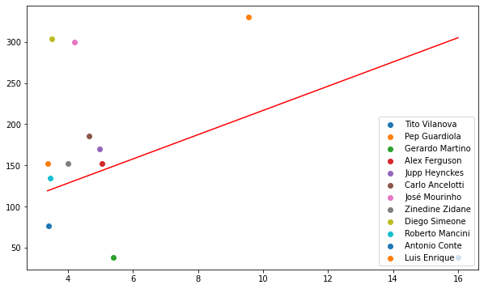

```python
top_5 = int(len(wl_df) * 0.05)
top_managers = wl_df.sort_values(by=['wl_ratio'], ascending=False)
top_managers = top_managers.nlargest(top_5, 'wl_ratio')
top_managers = top_managers.reset_index()

# plotting the top managers with their names labeled
plt.rcParams["figure.figsize"] = (10,6)

fig, ax = plt.subplots()

for m in top_managers['manager'].unique():
    manager = top_managers[top_managers['manager'] == m]
    plt.scatter(x=manager['wl_ratio'], y=manager['gp'], label=m)

ax.legend()

wl_ratio = np.array(top_managers["wl_ratio"]).reshape(-1, 1)
gp = np.array(top_managers["gp"]).reshape(-1, 1)
plt.plot(wl_ratio, reg1.intercept_ + reg1.coef_ * wl_ratio, '-', color='Red')
```

Now that only the top 5 percent of managers based on win loss ratio are displayed, we see which data actually supports our claim. The managers that fall above the regression line are the ones that are rather elite with Pep Guardiola being especially outstanding, with the highest number of games played and ratio outside of Tito Vilanova who has played less than 1/6 of the games that Guardiola has.

## Points-per-game

```python
manager_ft_draw = manager_ft_results[manager_ft_results['result'] == "D"]
manager_ft_draw['draw']= manager_ft_draw.groupby('manager')['result'].transform('count')
manager_ft_draw = manager_ft_draw.drop(columns=['result']).drop_duplicates()

# merging the inital data with wins and losses to our draw data
ppg_df = _df.merge(manager_ft_draw, on='manager')

def points_per_game(wins, draw, losses):
    # 3 points for wins and 1 point for a draw
    points = wins * 3 + draw
    games = wins + draw + losses
    return points / games


ppg_df['points'] = ppg_df.apply(lambda x: points_per_game(x.wins, x.draw, x.losses), axis=1)
ppg_df = ppg_df.sort_values(by=['points'], ascending=False)
ppg_df.head()
```

|  | manager | wins | losses | draws | gp | draw | points |
| --- | --- | --- | --- | --- | --- | --- | --- |
| 109 | Tito Vilanova | 32 | 2 | 4 | 38 | 4 | 2.631579 |
| 40 | Pep Guardiola | 258 | 27 | 45 | 330 | 45 | 2.481818 |
| 142 | Gerardo Martino | 27 | 5 | 6 | 38 | 6 | 2.289474 |
| 9 | Alex Ferguson | 106 | 21 | 25 | 152 | 25 | 2.256579 |
| 3 | Carlo Ancelotti | 130 | 28 | 28 | 186 | 28 | 2.247312 |

## Goals For-Against

```python
def goals_for_and_against(df):
    # Home goals table is from the point of view of the home manager
    # with FTHG (Full Time Home Goals) being for the manager and
    # FTAG (Full Time Away Goals) being against the manager
    home_goals = df[["h_manager", "FTHG", "FTAG"]]
    home_goals = home_goals.rename(columns={"h_manager": "manager", "FTHG": "goals_for", "FTAG": "goals_against"})

    # Away goals is the opposite of the home goals table
    away_goals = _full_data[["a_manager", "FTHG", "FTAG"]]
    away_goals = away_goals.rename(columns={"a_manager": "manager", "FTAG": "goals_for", "FTHG": "goals_against"})
    away_goals = away_goals[["manager", "goals_for", "goals_against"]]

    # Combining the home and away data
    goals_df = pd.concat([home_goals, away_goals], ignore_index=True)

    # aggregating the total goals for
    _goals1 = goals_df.copy()[["manager", "goals_for"]]
    _goals1['goals_for'] = _goals1.groupby('manager')['goals_for'].transform('sum')
    _goals1 = _goals1.drop_duplicates()

     # aggregating the total goals against
    _goals2 = goals_df.copy()[["manager", "goals_against"]]
    _goals2['goals_against'] = _goals2.groupby('manager')['goals_against'].transform('sum')
    _goals2 = _goals2.drop_duplicates()

     # aggregating the total games
    _goals3 = goals_df.copy()[["manager"]]
    _goals3['games'] = _goals3.groupby('manager')['manager'].transform('count')
    _goals3 = _goals3.drop_duplicates()

    # combining goals for-against and games
    _goals_table = _goals1.merge(_goals2, on='manager')
    goals_table = _goals_table.merge(_goals3, on='manager')

    # adding `net_goals_per_game` which means takes the average difference of goals
    # per game
    goals_table['net_goals_per_game'] = goals_table \
        .apply(lambda x: (x['goals_for'] - x['goals_against']) / x['games'], axis=1)

    goals_table = goals_table.sort_values(by=['net_goals_per_game'], ascending=False)
    return goals_table

goals_f_a = goals_for_and_against(_full_data.copy())
goals_f_a.head()
```

|  | manager | goals_for | goals_against | games | net_goals_per_game |
| --- | --- | --- | --- | --- | --- |
| 136 | Tito Vilanova | 115 | 40 | 38 | 1.973684 |
| 49 | Pep Guardiola | 842 | 221 | 330 | 1.881818 |
| 181 | Gerardo Martino | 100 | 33 | 38 | 1.763158 |
| 8 | Carlo Ancelotti | 483 | 163 | 186 | 1.720430 |
| 137 | Luis Enrique | 387 | 141 | 152 | 1.618421 |

## Evaluating Points-Per-Game

```python
# merging our three datasets that were processed
_manager_stats = ppg_df.merge(wl_df, on='manager')
manager_stats = _manager_stats.merge(goals_f_a, on='manager')
manager_stats.head()
```

|  | manager | wins | losses | draws | gp_x | draw | points | wl_ratio | gp_y | goals_for | goals_against | games | net_goals_per_game |
| --- | --- | --- | --- | --- | --- | --- | --- | --- | --- | --- | --- | --- | --- |
| 0 | Tito Vilanova | 32 | 2 | 4 | 38 | 4 | 2.631579 | 16.000000 | 38 | 115 | 40 | 38 | 1.973684 |
| 1 | Pep Guardiola | 258 | 27 | 45 | 330 | 45 | 2.481818 | 9.555556 | 330 | 842 | 221 | 330 | 1.881818 |
| 2 | Gerardo Martino | 27 | 5 | 6 | 38 | 6 | 2.289474 | 5.400000 | 38 | 100 | 33 | 38 | 1.763158 |
| 3 | Alex Ferguson | 106 | 21 | 25 | 152 | 25 | 2.256579 | 5.047619 | 152 | 341 | 142 | 152 | 1.309211 |
| 4 | Carlo Ancelotti | 130 | 28 | 28 | 186 | 28 | 2.247312 | 4.642857 | 186 | 483 | 163 | 186 | 1.720430 |

### Points per Game vs. Net Goals per Game

Here we plot the Points per Game against the Net Goals per Game and determine that there is a highly correlated linear relationship between the two.

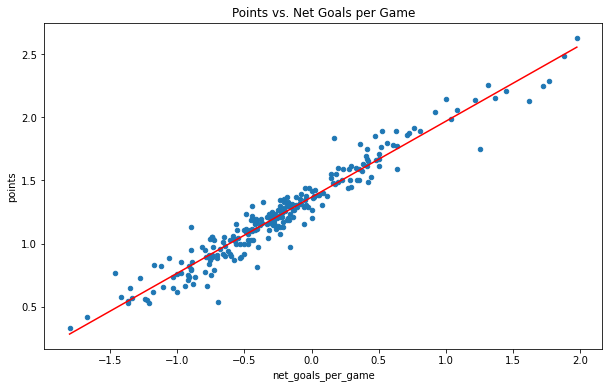

```python
# generating the scatter plot
ax = manager_stats.plot.scatter(x='net_goals_per_game', y='points', figsize=(10,6))

# generating the linear regression for the data
net_goals_per_game = np.array(manager_stats["net_goals_per_game"]).reshape(-1, 1)
points = np.array(manager_stats["points"]).reshape(-1, 1)
reg1 = LinearRegression().fit(net_goals_per_game, points)
plt.plot(net_goals_per_game, reg1.intercept_ + reg1.coef_ * net_goals_per_game, '-', color='Red')

plt.title("Points vs. Net Goals per Game")
```

To get an understanding of the top managers based on points and goals per game, we label the top 5% of managers by points.

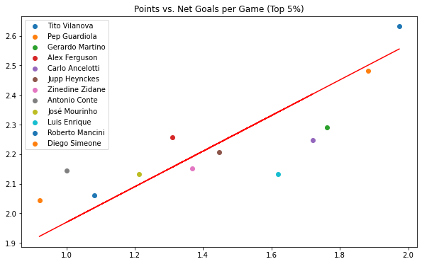

```python
# taking only the top 5% of managers
top_5 = int(len(manager_stats) * 0.05)
top_managers = manager_stats.sort_values(by=['points'], ascending=False)
top_managers = top_managers.nlargest(top_5, 'points')
top_managers = top_managers.reset_index()


# plotting the top managers with their names labeled
plt.rcParams["figure.figsize"] = (10,6)

fig, ax = plt.subplots()

for m in top_managers['manager'].unique():
    manager = top_managers[top_managers['manager'] == m]
    plt.scatter(x=manager['net_goals_per_game'], y=manager['points'], label=m)

ax.legend()

net_goals_per_game = np.array(top_managers["net_goals_per_game"]).reshape(-1, 1)
points = np.array(top_managers["points"]).reshape(-1, 1)
plt.plot(net_goals_per_game, reg1.intercept_ + reg1.coef_ * net_goals_per_game, '-', color='Red')

plt.title("Points vs. Net Goals per Game (Top 5%)")
```

### Points per Game vs. WL Ratio

Plotting the points per game against the win-loss ratio gives us a logarithmic relationship.

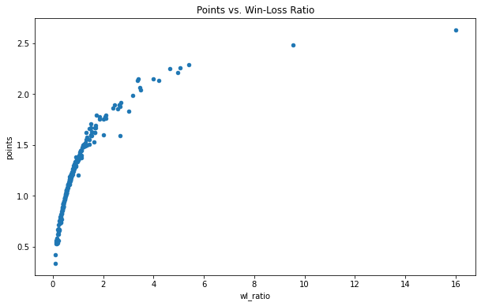

```python
ax = manager_stats.plot.scatter(x='wl_ratio', y='points', figsize=(10,6))
plt.title("Points vs. Win-Loss Ratio")
```

To get a better understanding of the relationship we take the log of the win-loss ratio and find a fairly linear reltaionship.

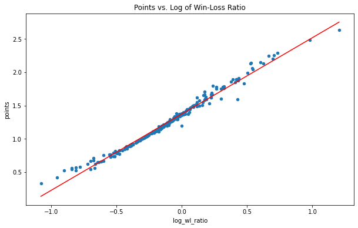

```python
# taking the log of `wl_ratio`
manager_stats['log_wl_ratio'] = np.log10(manager_stats['wl_ratio'])

# generating the scatter plot
ax = manager_stats.plot.scatter(x='log_wl_ratio', y='points', figsize=(10,6))

# generating the linear regression for the data
wl_ratio = np.array(manager_stats["log_wl_ratio"]).reshape(-1, 1)
points = np.array(manager_stats["points"]).reshape(-1, 1)
reg2 = LinearRegression().fit(wl_ratio, points)
plt.plot(wl_ratio, reg2.intercept_ + reg2.coef_ * wl_ratio, '-', color='Red')

plt.title("Points vs. Log of Win-Loss Ratio")
```

Again, we look at the top 5% of managers.

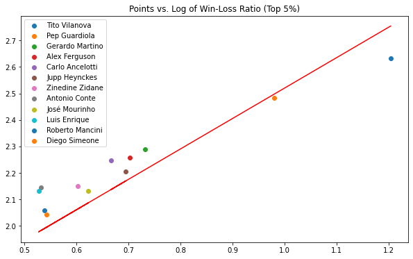

```python
# plotting the top managers with their names labeled
top_managers['log_wl_ratio'] = np.log10(top_managers['wl_ratio'])

plt.rcParams["figure.figsize"] = (10,6)

fig, ax = plt.subplots()

for m in top_managers['manager'].unique():
    manager = top_managers[top_managers['manager'] == m]
    plt.scatter(x=manager['log_wl_ratio'], y=manager['points'], label=m)

ax.legend()

wl_ratio = np.array(top_managers["log_wl_ratio"]).reshape(-1, 1)
points = np.array(top_managers["points"]).reshape(-1, 1)
plt.plot(wl_ratio, reg2.intercept_ + reg2.coef_ * wl_ratio, '-', color='Red')

plt.title("Points vs. Log of Win-Loss Ratio (Top 5%)")
```

# Generating a Model for Offensive and Defensive Minded Coaching

We investigate the importance of both offense and defense for coaching by standardizing an offensive and defensive score for the managers. The offensive rating is represented by the goals that are scored per game and defensive rating is the goals against per game time negative one to reward ratings near 0 (no goals against them).

```python
# collecting necessary columns and generating a priliminary rating system
_manager_ratings = manager_stats.copy()[["manager", "goals_for", "goals_against", "games", "points"]]
_manager_ratings['_offensive_rating'] = _manager_ratings.apply(lambda x: x['goals_for'] / x['games'], axis=1)
# a higher defensive rating should mean less goals against so we multiply by -1
_manager_ratings['_defensive_rating'] = _manager_ratings.apply(lambda x: -1 * (x['goals_against'] / x['games']), axis=1)
_manager_ratings = _manager_ratings.drop(columns=['goals_for', 'goals_against', 'games'])
_manager_ratings.head()
```

|  | manager | points | _offensive_rating | _defensive_rating |
| --- | --- | --- | --- | --- |
| 0 | Tito Vilanova | 2.631579 | 3.026316 | -1.052632 |
| 1 | Pep Guardiola | 2.481818 | 2.551515 | -0.669697 |
| 2 | Gerardo Martino | 2.289474 | 2.631579 | -0.868421 |
| 3 | Alex Ferguson | 2.256579 | 2.243421 | -0.934211 |
| 4 | Carlo Ancelotti | 2.247312 | 2.596774 | -0.876344 |

```python
avg_offense = np.average(_manager_ratings['_offensive_rating'])
avg_defense = np.average(_manager_ratings['_defensive_rating'])
print("Average Offense: ", avg_offense, "\t Average Defense: ", avg_defense)
```

```
Average Offense:  1.2822130790993436 	 Average Defense:  -1.5150266807474957
```

```python
manager_ratings = _manager_ratings.copy()
# with the average offense and defense we standardize the rating system
manager_ratings['offensive_rating'] = manager_ratings.apply(lambda x: x['_offensive_rating'] - avg_offense, axis=1)
manager_ratings['defensive_rating'] = manager_ratings.apply(lambda x: x['_defensive_rating'] - avg_defense, axis=1)
manager_ratings = manager_ratings.drop(columns=['_offensive_rating', '_defensive_rating'])
manager_ratings.head()
```

|  | manager | points | offensive_rating | defensive_rating |
| --- | --- | --- | --- | --- |
| 0 | Tito Vilanova | 2.631579 | 1.744103 | 0.462395 |
| 1 | Pep Guardiola | 2.481818 | 1.269302 | 0.845330 |
| 2 | Gerardo Martino | 2.289474 | 1.349366 | 0.646606 |
| 3 | Alex Ferguson | 2.256579 | 0.961208 | 0.580816 |
| 4 | Carlo Ancelotti | 2.247312 | 1.314561 | 0.638683 |

Here we plot points against both the offensive and defensive rating systems to test for a linear relationship

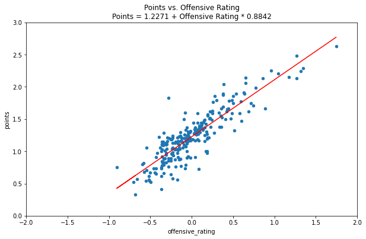

```python
ax = manager_ratings.plot.scatter(x='offensive_rating', y='points', figsize=(10,6))
ax.set_xlim([-2, 2])
ax.set_ylim([0, 3])

offensive_rating = np.array(manager_ratings["offensive_rating"]).reshape(-1, 1)
points = np.array(manager_ratings["points"]).reshape(-1, 1)
reg_offense = LinearRegression().fit(offensive_rating, points)

equation = "Points = {0:.4f} + Offensive Rating * {1:.4f}" \
    .format(reg_offense.intercept_[0], reg_offense.coef_[0][0])
plt.title("Points vs. Offensive Rating\n" + equation)

plt.plot(offensive_rating, reg_offense.intercept_ + reg_offense.coef_ * offensive_rating, '-', color='Red')
```

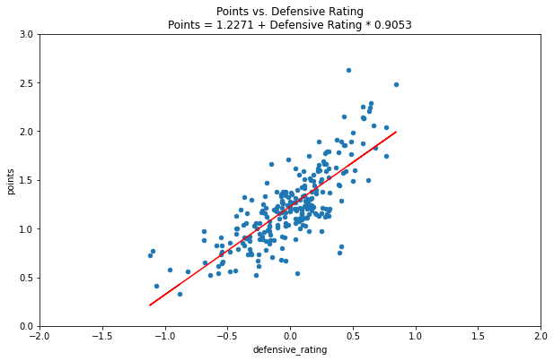

```python
ax = manager_ratings.plot.scatter(x='defensive_rating', y='points', figsize=(10,6))
ax.set_xlim([-2, 2])
ax.set_ylim([0, 3])

defensive_rating = np.array(manager_ratings["defensive_rating"]).reshape(-1, 1)
points = np.array(manager_ratings["points"]).reshape(-1, 1)
reg_defense = LinearRegression().fit(defensive_rating, points)

equation = "Points = {0:.4f} + Defensive Rating * {1:.4f}" \
    .format(reg_defense.intercept_[0], reg_defense.coef_[0][0])
plt.title("Points vs. Defensive Rating\n" + equation)

plt.plot(defensive_rating, reg_defense.intercept_ + reg_defense.coef_ * defensive_rating, '-', color='Red')
```

Interestingly, the defensive rating has a higher slope and theoretically a higher impact points per game for managers. The more spread-out data for offensive rating makes sense as larger teams can have high scoring games against weaker opponents, but defense is bounded by 0 for each game.

Using both of the offensive and defensive ratings, we produce a model to predict the points per game of a manager. First we generate a training data set and then a testing data set with 70% and 30% of the data, respectivly.

```python
train, test = train_test_split(manager_ratings.drop('manager', 1), test_size=0.30, shuffle=True)
```

Using the training data we create a Linear Regression model using the offensive and defensive ratings and print the resulting equation.

```python
X = train.drop('points', 1)
y = train['points']

# generate linear regression from test data
lr = LinearRegression()
lr.fit(X, y)

# print the results
used_features = ['Offensive Rating', 'Defensive Rating']

coef_str = ""
for i in range(0, len(lr.coef_)):
    coef_str = coef_str + "({0:.3f} * {1}) + ".format(lr.coef_[i], used_features[i])

coef_str = coef_str[:-2]

print("Points = {0:.3f} + ".format(lr.intercept_) + coef_str)
```

```
Points = 1.228 + (0.648 * Offensive Rating) + (0.539 * Defensive Rating)
```

```python
def predict_points(row):
    return lr.predict([[ row.offensive_rating, row.defensive_rating]])[0]

# generate our predicitons using the new model
test['prediction'] = test.apply(lambda x: predict_points(x), axis=1)
# generate our residuals from the model
test['residual'] = test['points'] - test['prediction']
test
```

|  | points | offensive_rating | defensive_rating | prediction | residual |
| --- | --- | --- | --- | --- | --- |
| 48 | 1.520000 | 0.221787 | 0.155027 | 1.454878 | 0.065122 |
| 133 | 1.169118 | 0.085434 | -0.065856 | 1.247478 | -0.078361 |
| 65 | 1.381579 | 0.112524 | 0.172921 | 1.393693 | -0.012114 |
| 143 | 1.149123 | -0.361160 | 0.208009 | 1.105546 | 0.043577 |
| 151 | 1.117647 | -0.061625 | -0.190856 | 1.084801 | 0.032846 |
| ... | ... | ... | ... | ... | ... |
| 2 | 2.289474 | 1.349366 | 0.646606 | 2.450666 | -0.161192 |
| 68 | 1.375000 | 0.092787 | 0.257674 | 1.426564 | -0.051564 |
| 139 | 1.157895 | -0.295371 | 0.199237 | 1.143465 | 0.014429 |
| 135 | 1.164474 | 0.040155 | -0.228394 | 1.130551 | 0.033923 |
| 62 | 1.414634 | 0.120226 | 0.112588 | 1.366178 | 0.048457 |

75 rows × 5 columns

The average season for soccer is 38 games, so scaling up the data to a season can give a more representative understanding of the accuracy of our model. The residuals increase to show how far we our model is in terms of a full season's points.

```python
scaled_results = test.copy()
# scaling the results to a full season of 38 games
scaled_results['points_per_season'] = test.apply(lambda x: x['points'] * 38, 1)
scaled_results['prediction'] = test.apply(lambda x: x['prediction'] * 38, 1)
# recalculating the residuals
scaled_results['residual'] = scaled_results['points_per_season'] - scaled_results['prediction']
scaled_results = scaled_results[["points_per_season", "prediction", "residual"]]
scaled_results.head()
```

|  | points_per_season | prediction | residual |
| --- | --- | --- | --- |
| 48 | 57.760000 | 55.285364 | 2.474636 |
| 133 | 44.426471 | 47.404177 | -2.977706 |
| 65 | 52.500000 | 52.960332 | -0.460332 |
| 143 | 43.666667 | 42.010733 | 1.655933 |
| 151 | 42.470588 | 41.222430 | 1.248158 |

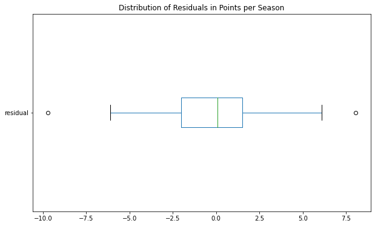

```python
scaled_results['residual'].plot.box(title='Distribution of Residuals in Points per Season', vert=False)
```

Excluding the outliers, the model predicted within 7.5 points, the average points per season for managers. The model is based on the offensive and defensive standardized ratings for each manager along with the recorded points per game for the manager.

## Conclusion

The data that was gathered and analyzed yielded some surprising names for best managers and some names that were not so surprising. Some of those names include Tito Vilanova, Pep Guardiola, Gerardo Martino, Sir Alex Ferguson, and Carlo Ancelotti. These are some of the names that are consistently shining throughout all of the data analysis.

Starting with the win-loss ratio, these men all have very high win-loss ratios but the discrepancy with this data is that Tito Vilanova and Gerardo Martino have played a fraction of games compared to some of the other names on this list. This was one of the bigger concerns with the data analysis in general, as some names might appear too high or low on the list of managers based solely upon the number of games played. After that is the points per game analysis, which is one of the most important aspects of soccer because points are what wins championships. In soccer one point is awarded for a draw, zero for a loss, and three points for a win. And the analysis shows that the same names show up for the average points per game, meaning that their record mostly consists of wins. Net goals was another thing that was analyzed, which shows how many goals they score per game and how many goals they get scored on them, on average. Unsurprisingly, the same names pop up with the highest net goals per game coming out to almost two which is very high for soccer matches. Now comparing the points and net goals showed that there is some link between the two statistics and the top managers are near and around the top of the regression line again. Next analysis was the plotting of points per game compared to the win loss ratio. This yielded data that shows that the two statistics are very closely related, with almost all points falling on the regression line. Finally we generated a model for offensive and defensive minded coaching in an attempt to see if one mindset creates more success than the other. The results showed that the two are both very important but defensive mindset seems to be constant whereas an offensive mindset can give varying results based on the opponent’s team. Using the data yielded from the offensive and defensive analysis, an offensive and defensive rating can be assigned to each manager and a regression model can be run to predict the points per season of each manager. The data from this yielded fairly accurate results with most residuals being only a few points off from the regression, within 7.5 points to be exact.